# Homework, by Huanyu Liu, Feb 19, 2019

## Executive Summary

This assignment creates a report that compares the data and results from my homework2 and homework3 with other's.

## Full Body Text

For homework2, it compares the dividend dates returns with non-dividend dates returns. However, I used holding period return to calculate both the returns. While my teammate used returns with out dividend.

## Tables and Figures

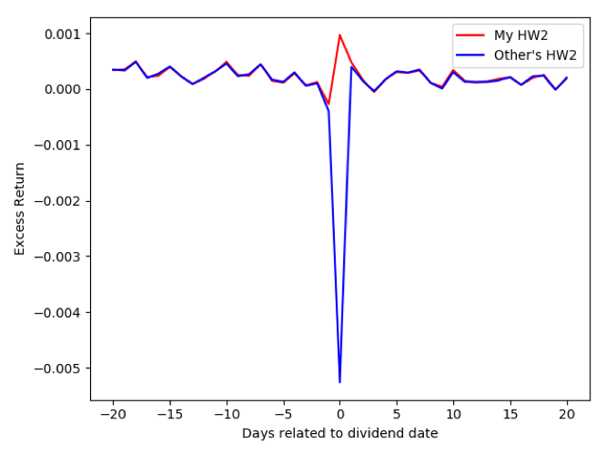

From the figure above, we can see that the returns on non-dividend dates are very similar, while the return on dividends dates are totally different because one is total holding period return while the other is return with out dividends

For homework3, we compared the average returns based on different market capacity. I used the companies PERMNO's that begin with 100, while he used all the companies' data.

My table and figure:

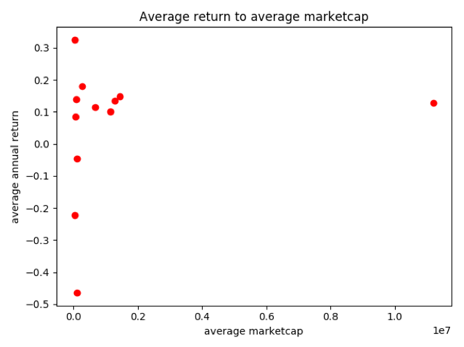

My Data

| PERMNO | Average Annual Return | Average Market Capacity |  |
| --- | --- | --- | --- |
| 10001 | 0.138971 | 7.80E+04 |  |
| 10002 | -0.045405 | 1.05E+05 |  |
| 10025 | 0.180349 | 2.61E+05 |  |
| 10026 | 0.149164 | 1.45E+06 |  |
| 10028 | 0.325233 | 2.96E+04 |  |
| 10032 | 0.135212 | 1.28E+06 |  |
| 10042 | -0.221178 | 2.53E+04 |  |
| 10044 | 0.084678 | 6.65E+04 |  |
| 10051 | 0.113992 | 6.65E+05 |  |
| 10065 | 0.10013 | 1.14E+06 |  |
| 10078 | 0.128154 | 1.12E+07 |  |
| 10092 | -0.464624 | 1.04E+05 |  |

His Figure

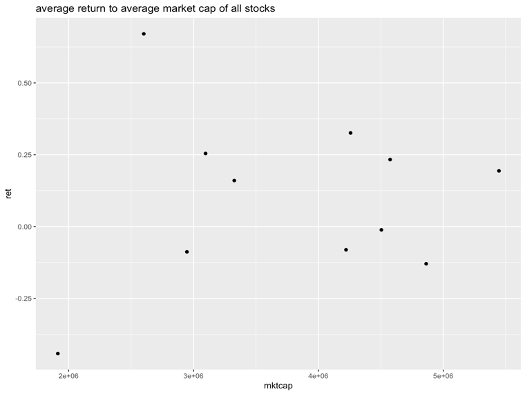

From the pictures above, my small sample of companies gives a result that most of the companies have an annual return around 5% to 20%. And small market cap companies tend to have more volatility.  
However, with a large sample, we can see that the returns seems uncorrelated with the company market capacity. However, both the extreme high and low returns are small market cap companies.

## Computer Code

For the code, I used Python for the assignment, while he used R.

```
      # hw2
import pandas as pd
import numpy as np
import matplotlib.pyplot as plt

df = pd.read_csv("~/Desktop/CorporateFinance404/hw2/sp500.csv")
df = df.replace('C',0)
dividend_date = df.dropna().index.values
non_dividend = list()
return_mean = list()

for i in range(-20,21):
    x = [j + i for j in dividend_date]
    non_dividend.append(x)


for i in non_dividend:
    temp = df.iloc[i,3].astype("float").subtract(df.iloc[i,4])
    return_mean.append(np.mean(temp))

plt.plot([i for i in range(-20,21)],return_mean, 'r', label = 'My HW2')
plt.ylabel("Excess Return")
plt.xlabel("Days related to dividend date")

df2_other = pd.read_csv("~/Desktop/CorporateFinance404/hw5/hw2.csv")
df2_other = df2_other.replace('C',0)
dividend_date_other = df2_other.dropna().index.values
non_dividend_other = list()
return_mean_other = list()
for i in range(-20,21):
    x = [j + i for j in dividend_date_other]
    non_dividend_other.append(x)
for i in non_dividend_other:
    temp = df2_other.iloc[i,5].astype("float").subtract(df2_other.iloc[i,6])
    return_mean_other.append(np.mean(temp))

plt.plot([i for i in range(-20,21)],return_mean_other,'b', label = "Other's HW2")
plt.legend()
plt.show()


# HW3

df3 = pd.read_csv("~/Desktop/CorporateFinance404/hw5/hw3_huanyu.csv")
df3 = df3.replace('C',0)
df3 = df3.dropna()
df3['date'] = pd.to_datetime(df3['date'],format='%Y%m%d')
permno = df3['PERMNO'].unique()
no_comp = len(permno)
returns = np.zeros(no_comp)
market_cap = np.zeros(no_comp)

for i in range(no_comp):
    daily_return = df3[df3['PERMNO'] == permno[i]]
    sum = 0
    count = 0
    for j in range(2007,2018):
        annual = daily_return[(daily_return['date'] < str(j+1) + '-01-01') & (daily_return['date'] > str(j) + '-01-01')]
        if len(annual) > 0:
            count += 1
            annual_return = np.prod(annual['RET'].astype('float') + 1) - 1
            sum += annual_return
    returns[i] = sum / count


for i in range(no_comp):
    market_cap[i] = np.mean(np.absolute(df3[df3['PERMNO'] == permno[i]]['PRC'].astype('float')) * df3[df3['PERMNO'] == permno[i]]['SHROUT'].astype('float'))

summary = pd.DataFrame({'average_return':returns,'average marketcap': market_cap})
summary = summary.set_index(permno)

plt.plot(summary['average marketcap'],summary['average_return'],'ro')
plt.xlabel('average marketcap')
plt.ylabel('average annual return')
plt.title('Average return to average marketcap')
plt.show()
```

## References

- [CRSP](https://wrds-web.wharton.upenn.edu/wrds/ds/crsp/stock_a/dsf.cfm?navId=128)

TAs, please do not judge me too harshly.